# Risk Factor Analysis

## Outcome Variable

**Outcome Variable:** ever_co

## Predictor Variables

**Intervention Variable:** meducyrs

**Adjustment Set:**

- arm
- W_mage
- feducyrs
- hhwealth_quart
- W_mhtcm
- W_mwtkg
- W_mbmi
- W_gagebrth
- W_birthwt
- W_birthlen
- single
- impsan
- delta_W_mage
- delta_feducyrs
- delta_hhwealth_quart
- delta_W_mhtcm
- delta_W_mwtkg
- delta_W_mbmi
- delta_W_gagebrth
- delta_W_birthwt
- delta_W_birthlen
- delta_single
- delta_impsan

## Stratifying Variables

The analysis was stratified on these variable(s):

- agecat
- studyid
- country

## Data Summary

| agecat | studyid | country | meducyrs | ever_co | n_cell | n |
| --- | --- | --- | --- | --- | --- | --- |
| 0-24 months | ki0047075b-MAL-ED | BANGLADESH | High | 0 | 70 | 213 |
| 0-24 months | ki0047075b-MAL-ED | BANGLADESH | High | 1 | 8 | 213 |
| 0-24 months | ki0047075b-MAL-ED | BANGLADESH | Low | 0 | 61 | 213 |
| 0-24 months | ki0047075b-MAL-ED | BANGLADESH | Low | 1 | 9 | 213 |
| 0-24 months | ki0047075b-MAL-ED | BANGLADESH | Medium | 0 | 58 | 213 |
| 0-24 months | ki0047075b-MAL-ED | BANGLADESH | Medium | 1 | 7 | 213 |
| 0-24 months | ki0047075b-MAL-ED | BRAZIL | High | 0 | 79 | 232 |
| 0-24 months | ki0047075b-MAL-ED | BRAZIL | High | 1 | 0 | 232 |
| 0-24 months | ki0047075b-MAL-ED | BRAZIL | Low | 0 | 61 | 232 |
| 0-24 months | ki0047075b-MAL-ED | BRAZIL | Low | 1 | 2 | 232 |
| 0-24 months | ki0047075b-MAL-ED | BRAZIL | Medium | 0 | 89 | 232 |
| 0-24 months | ki0047075b-MAL-ED | BRAZIL | Medium | 1 | 1 | 232 |
| 0-24 months | ki0047075b-MAL-ED | INDIA | High | 0 | 54 | 220 |
| 0-24 months | ki0047075b-MAL-ED | INDIA | High | 1 | 9 | 220 |
| 0-24 months | ki0047075b-MAL-ED | INDIA | Low | 0 | 61 | 220 |
| 0-24 months | ki0047075b-MAL-ED | INDIA | Low | 1 | 15 | 220 |
| 0-24 months | ki0047075b-MAL-ED | INDIA | Medium | 0 | 60 | 220 |
| 0-24 months | ki0047075b-MAL-ED | INDIA | Medium | 1 | 21 | 220 |
| 0-24 months | ki0047075b-MAL-ED | NEPAL | High | 0 | 50 | 225 |
| 0-24 months | ki0047075b-MAL-ED | NEPAL | High | 1 | 3 | 225 |
| 0-24 months | ki0047075b-MAL-ED | NEPAL | Low | 0 | 84 | 225 |
| 0-24 months | ki0047075b-MAL-ED | NEPAL | Low | 1 | 12 | 225 |
| 0-24 months | ki0047075b-MAL-ED | NEPAL | Medium | 0 | 71 | 225 |
| 0-24 months | ki0047075b-MAL-ED | NEPAL | Medium | 1 | 5 | 225 |
| 0-24 months | ki0047075b-MAL-ED | PERU | High | 0 | 89 | 301 |
| 0-24 months | ki0047075b-MAL-ED | PERU | High | 1 | 1 | 301 |
| 0-24 months | ki0047075b-MAL-ED | PERU | Low | 0 | 100 | 301 |
| 0-24 months | ki0047075b-MAL-ED | PERU | Low | 1 | 4 | 301 |
| 0-24 months | ki0047075b-MAL-ED | PERU | Medium | 0 | 100 | 301 |
| 0-24 months | ki0047075b-MAL-ED | PERU | Medium | 1 | 7 | 301 |

[output cut: 438 more lines]

The following strata were considered:

- agecat: 0-24 months, studyid: ki0047075b-MAL-ED, country: BANGLADESH
- agecat: 0-24 months, studyid: ki0047075b-MAL-ED, country: BRAZIL
- agecat: 0-24 months, studyid: ki0047075b-MAL-ED, country: INDIA
- agecat: 0-24 months, studyid: ki0047075b-MAL-ED, country: NEPAL
- agecat: 0-24 months, studyid: ki0047075b-MAL-ED, country: PERU
- agecat: 0-24 months, studyid: ki0047075b-MAL-ED, country: SOUTH AFRICA
- agecat: 0-24 months, studyid: ki0047075b-MAL-ED, country: TANZANIA, UNITED REPUBLIC OF
- agecat: 0-24 months, studyid: ki1000108-CMC-V-BCS-2002, country: INDIA
- agecat: 0-24 months, studyid: ki1000108-IRC, country: INDIA
- agecat: 0-24 months, studyid: ki1000109-EE, country: PAKISTAN
- agecat: 0-24 months, studyid: ki1000304b-SAS-CompFeed, country: INDIA
- agecat: 0-24 months, studyid: ki1000304b-SAS-FoodSuppl, country: INDIA
- agecat: 0-24 months, studyid: ki1017093-NIH-Birth, country: BANGLADESH
- agecat: 0-24 months, studyid: ki1017093b-PROVIDE, country: BANGLADESH
- agecat: 0-24 months, studyid: ki1017093c-NIH-Crypto, country: BANGLADESH
- agecat: 0-24 months, studyid: ki1066203-TanzaniaChild2, country: TANZANIA, UNITED REPUBLIC OF
- agecat: 0-24 months, studyid: ki1112895-Guatemala BSC, country: GUATEMALA
- agecat: 0-24 months, studyid: ki1113344-GMS-Nepal, country: NEPAL
- agecat: 0-24 months, studyid: ki1119695-PROBIT, country: BELARUS
- agecat: 0-24 months, studyid: ki1126311-ZVITAMBO, country: ZIMBABWE
- agecat: 0-24 months, studyid: ki1135781-COHORTS, country: GUATEMALA
- agecat: 0-24 months, studyid: ki1135781-COHORTS, country: INDIA
- agecat: 0-24 months, studyid: ki1135781-COHORTS, country: PHILIPPINES
- agecat: 0-24 months, studyid: ki1148112-LCNI-5, country: MALAWI
- agecat: 0-24 months, studyid: kiGH5241-JiVitA-3, country: BANGLADESH
- agecat: 0-24 months, studyid: kiGH5241-JiVitA-4, country: BANGLADESH
- agecat: 0-6 months, studyid: ki0047075b-MAL-ED, country: BANGLADESH
- agecat: 0-6 months, studyid: ki0047075b-MAL-ED, country: BRAZIL
- agecat: 0-6 months, studyid: ki0047075b-MAL-ED, country: INDIA
- agecat: 0-6 months, studyid: ki0047075b-MAL-ED, country: NEPAL
- agecat: 0-6 months, studyid: ki0047075b-MAL-ED, country: PERU
- agecat: 0-6 months, studyid: ki0047075b-MAL-ED, country: SOUTH AFRICA
- agecat: 0-6 months, studyid: ki0047075b-MAL-ED, country: TANZANIA, UNITED REPUBLIC OF
- agecat: 0-6 months, studyid: ki1000108-CMC-V-BCS-2002, country: INDIA
- agecat: 0-6 months, studyid: ki1000108-IRC, country: INDIA
- agecat: 0-6 months, studyid: ki1000109-EE, country: PAKISTAN
- agecat: 0-6 months, studyid: ki1000304b-SAS-CompFeed, country: INDIA
- agecat: 0-6 months, studyid: ki1000304b-SAS-FoodSuppl, country: INDIA
- agecat: 0-6 months, studyid: ki1017093-NIH-Birth, country: BANGLADESH
- agecat: 0-6 months, studyid: ki1017093b-PROVIDE, country: BANGLADESH
- agecat: 0-6 months, studyid: ki1017093c-NIH-Crypto, country: BANGLADESH
- agecat: 0-6 months, studyid: ki1066203-TanzaniaChild2, country: TANZANIA, UNITED REPUBLIC OF
- agecat: 0-6 months, studyid: ki1112895-Guatemala BSC, country: GUATEMALA
- agecat: 0-6 months, studyid: ki1113344-GMS-Nepal, country: NEPAL
- agecat: 0-6 months, studyid: ki1119695-PROBIT, country: BELARUS
- agecat: 0-6 months, studyid: ki1126311-ZVITAMBO, country: ZIMBABWE
- agecat: 0-6 months, studyid: ki1135781-COHORTS, country: GUATEMALA
- agecat: 0-6 months, studyid: ki1135781-COHORTS, country: INDIA
- agecat: 0-6 months, studyid: ki1135781-COHORTS, country: PHILIPPINES
- agecat: 0-6 months, studyid: ki1148112-LCNI-5, country: MALAWI
- agecat: 0-6 months, studyid: kiGH5241-JiVitA-3, country: BANGLADESH
- agecat: 0-6 months, studyid: kiGH5241-JiVitA-4, country: BANGLADESH
- agecat: 6-24 months, studyid: ki0047075b-MAL-ED, country: BANGLADESH
- agecat: 6-24 months, studyid: ki0047075b-MAL-ED, country: BRAZIL
- agecat: 6-24 months, studyid: ki0047075b-MAL-ED, country: INDIA
- agecat: 6-24 months, studyid: ki0047075b-MAL-ED, country: NEPAL
- agecat: 6-24 months, studyid: ki0047075b-MAL-ED, country: PERU
- agecat: 6-24 months, studyid: ki0047075b-MAL-ED, country: SOUTH AFRICA
- agecat: 6-24 months, studyid: ki0047075b-MAL-ED, country: TANZANIA, UNITED REPUBLIC OF
- agecat: 6-24 months, studyid: ki1000108-CMC-V-BCS-2002, country: INDIA
- agecat: 6-24 months, studyid: ki1000108-IRC, country: INDIA
- agecat: 6-24 months, studyid: ki1000109-EE, country: PAKISTAN
- agecat: 6-24 months, studyid: ki1000304b-SAS-CompFeed, country: INDIA
- agecat: 6-24 months, studyid: ki1000304b-SAS-FoodSuppl, country: INDIA
- agecat: 6-24 months, studyid: ki1017093-NIH-Birth, country: BANGLADESH
- agecat: 6-24 months, studyid: ki1017093b-PROVIDE, country: BANGLADESH
- agecat: 6-24 months, studyid: ki1017093c-NIH-Crypto, country: BANGLADESH
- agecat: 6-24 months, studyid: ki1066203-TanzaniaChild2, country: TANZANIA, UNITED REPUBLIC OF
- agecat: 6-24 months, studyid: ki1112895-Guatemala BSC, country: GUATEMALA
- agecat: 6-24 months, studyid: ki1113344-GMS-Nepal, country: NEPAL
- agecat: 6-24 months, studyid: ki1119695-PROBIT, country: BELARUS
- agecat: 6-24 months, studyid: ki1126311-ZVITAMBO, country: ZIMBABWE
- agecat: 6-24 months, studyid: ki1135781-COHORTS, country: GUATEMALA
- agecat: 6-24 months, studyid: ki1135781-COHORTS, country: INDIA
- agecat: 6-24 months, studyid: ki1135781-COHORTS, country: PHILIPPINES
- agecat: 6-24 months, studyid: ki1148112-LCNI-5, country: MALAWI
- agecat: 6-24 months, studyid: kiGH5241-JiVitA-3, country: BANGLADESH
- agecat: 6-24 months, studyid: kiGH5241-JiVitA-4, country: BANGLADESH

### Dropped Strata

Some strata were dropped due to rare outcomes:

- agecat: 0-24 months, studyid: ki0047075b-MAL-ED, country: BRAZIL
- agecat: 0-24 months, studyid: ki0047075b-MAL-ED, country: NEPAL
- agecat: 0-24 months, studyid: ki0047075b-MAL-ED, country: PERU
- agecat: 0-24 months, studyid: ki0047075b-MAL-ED, country: SOUTH AFRICA
- agecat: 0-24 months, studyid: ki0047075b-MAL-ED, country: TANZANIA, UNITED REPUBLIC OF
- agecat: 0-24 months, studyid: ki1000109-EE, country: PAKISTAN
- agecat: 0-24 months, studyid: ki1112895-Guatemala BSC, country: GUATEMALA
- agecat: 0-24 months, studyid: ki1119695-PROBIT, country: BELARUS
- agecat: 0-6 months, studyid: ki0047075b-MAL-ED, country: BANGLADESH
- agecat: 0-6 months, studyid: ki0047075b-MAL-ED, country: BRAZIL
- agecat: 0-6 months, studyid: ki0047075b-MAL-ED, country: INDIA
- agecat: 0-6 months, studyid: ki0047075b-MAL-ED, country: NEPAL
- agecat: 0-6 months, studyid: ki0047075b-MAL-ED, country: PERU
- agecat: 0-6 months, studyid: ki0047075b-MAL-ED, country: SOUTH AFRICA
- agecat: 0-6 months, studyid: ki0047075b-MAL-ED, country: TANZANIA, UNITED REPUBLIC OF
- agecat: 0-6 months, studyid: ki1000109-EE, country: PAKISTAN
- agecat: 0-6 months, studyid: ki1000304b-SAS-FoodSuppl, country: INDIA
- agecat: 0-6 months, studyid: ki1017093c-NIH-Crypto, country: BANGLADESH
- agecat: 0-6 months, studyid: ki1066203-TanzaniaChild2, country: TANZANIA, UNITED REPUBLIC OF
- agecat: 0-6 months, studyid: ki1112895-Guatemala BSC, country: GUATEMALA
- agecat: 0-6 months, studyid: ki1113344-GMS-Nepal, country: NEPAL
- agecat: 0-6 months, studyid: ki1119695-PROBIT, country: BELARUS
- agecat: 0-6 months, studyid: ki1135781-COHORTS, country: GUATEMALA
- agecat: 0-6 months, studyid: ki1148112-LCNI-5, country: MALAWI
- agecat: 6-24 months, studyid: ki0047075b-MAL-ED, country: BRAZIL
- agecat: 6-24 months, studyid: ki0047075b-MAL-ED, country: NEPAL
- agecat: 6-24 months, studyid: ki0047075b-MAL-ED, country: PERU
- agecat: 6-24 months, studyid: ki0047075b-MAL-ED, country: SOUTH AFRICA
- agecat: 6-24 months, studyid: ki0047075b-MAL-ED, country: TANZANIA, UNITED REPUBLIC OF
- agecat: 6-24 months, studyid: ki1000109-EE, country: PAKISTAN
- agecat: 6-24 months, studyid: ki1112895-Guatemala BSC, country: GUATEMALA
- agecat: 6-24 months, studyid: ki1119695-PROBIT, country: BELARUS

## Methods Detail

We’re interested in the causal parameters $E[Y_a]$ for all values of $a \in \mathcal{A}$. These parameters represent the mean outcome if, possibly contrary to fact, we intervened to set all units to have $A=a$. Under the randomization and positivity assumptions, these are identified by the statistical parameters $\psi_a=E_W[E_{Y|A,W}(Y|A=a,W)]$. In addition, we’re interested in the mean of $Y$, $E[Y]$ under no intervention (the observed mean). We will estimate these parameters by using SuperLearner to fit the relevant likelihood factors – $E_{Y|A,W}(Y|A=a,W)$ and $p(A=a|W)$, and then updating our likelihood fit using a joint TMLE.

For unadjusted analyses ($W=\{\}$), initial likelihoods were estimated using Lrnr_glm to estimate the simple $E(Y|A)$ and Lrnr_mean to estimate $p(A)$. For adjusted analyses, a small library containing Lrnr_glmnet, Lrnr_xgboost, and Lrnr_mean was used.

Having estimated these parameters, we will then use the delta method to estimate relative risks and attributable risks relative to a prespecified baseline level of $A$.

# Results Detail

## Results Plots

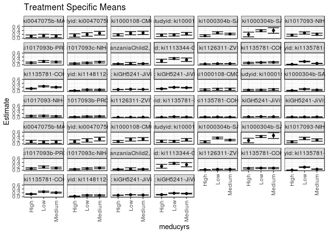

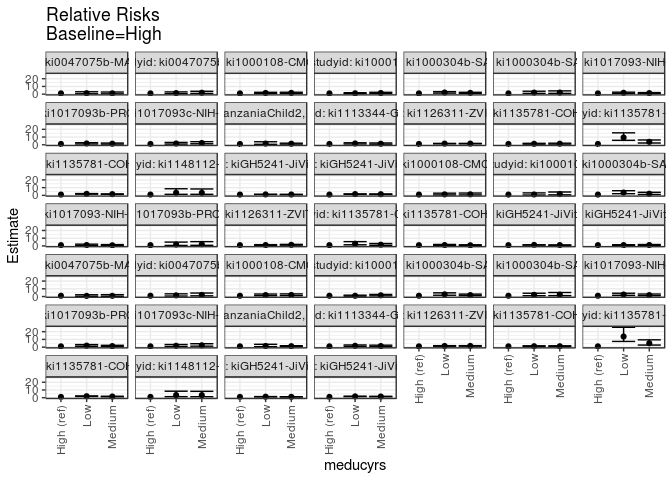

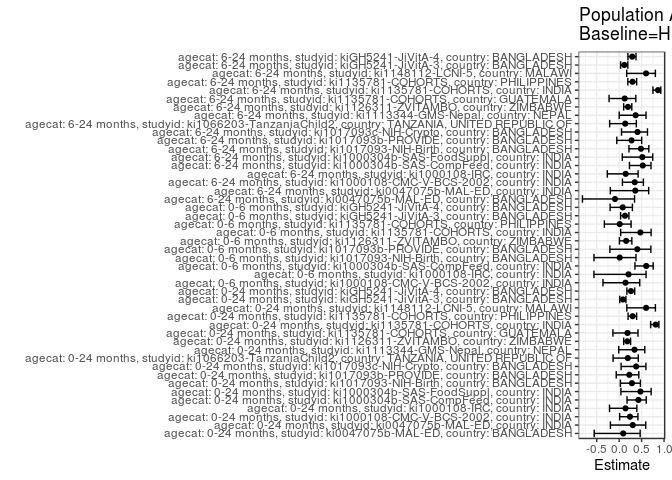

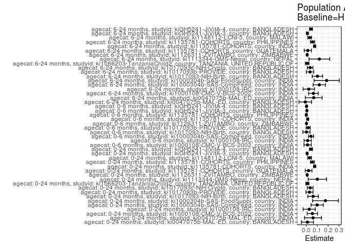

## Results Table

### Parameter: TSM

| agecat | studyid | country | intervention_level | baseline_level | estimate | ci_lower | ci_upper |
| --- | --- | --- | --- | --- | --- | --- | --- |
| 0-24 months | ki0047075b-MAL-ED | BANGLADESH | High | NA | 0.1025641 | 0.0350768 | 0.1700514 |
| 0-24 months | ki0047075b-MAL-ED | BANGLADESH | Low | NA | 0.1285714 | 0.0499739 | 0.2071690 |
| 0-24 months | ki0047075b-MAL-ED | BANGLADESH | Medium | NA | 0.1076923 | 0.0321547 | 0.1832299 |
| 0-24 months | ki0047075b-MAL-ED | INDIA | High | NA | 0.1428571 | 0.0562518 | 0.2294625 |
| 0-24 months | ki0047075b-MAL-ED | INDIA | Low | NA | 0.1973684 | 0.1076818 | 0.2870550 |
| 0-24 months | ki0047075b-MAL-ED | INDIA | Medium | NA | 0.2592593 | 0.1636070 | 0.3549115 |
| 0-24 months | ki1000108-CMC-V-BCS-2002 | INDIA | High | NA | 0.1749463 | 0.1178114 | 0.2320811 |
| 0-24 months | ki1000108-CMC-V-BCS-2002 | INDIA | Low | NA | 0.2616037 | 0.1771226 | 0.3460849 |
| 0-24 months | ki1000108-CMC-V-BCS-2002 | INDIA | Medium | NA | 0.2773504 | 0.1930752 | 0.3616255 |
| 0-24 months | ki1000108-IRC | INDIA | High | NA | 0.1590487 | 0.0948762 | 0.2232212 |
| 0-24 months | ki1000108-IRC | INDIA | Low | NA | 0.1729061 | 0.1116626 | 0.2341495 |
| 0-24 months | ki1000108-IRC | INDIA | Medium | NA | 0.2315562 | 0.1611694 | 0.3019430 |
| 0-24 months | ki1000304b-SAS-CompFeed | INDIA | High | NA | 0.1327069 | 0.0861811 | 0.1792328 |
| 0-24 months | ki1000304b-SAS-CompFeed | INDIA | Low | NA | 0.2789709 | 0.2234436 | 0.3344982 |
| 0-24 months | ki1000304b-SAS-CompFeed | INDIA | Medium | NA | 0.2197183 | 0.1787960 | 0.2606406 |
| 0-24 months | ki1000304b-SAS-FoodSuppl | INDIA | High | NA | 0.1951220 | 0.0736728 | 0.3165711 |
| 0-24 months | ki1000304b-SAS-FoodSuppl | INDIA | Low | NA | 0.3885542 | 0.3360609 | 0.4410475 |
| 0-24 months | ki1000304b-SAS-FoodSuppl | INDIA | Medium | NA | 0.4000000 | 0.2566929 | 0.5433071 |
| 0-24 months | ki1017093-NIH-Birth | BANGLADESH | High | NA | 0.1572011 | 0.1033377 | 0.2110645 |
| 0-24 months | ki1017093-NIH-Birth | BANGLADESH | Low | NA | 0.2711138 | 0.2135082 | 0.3287195 |
| 0-24 months | ki1017093-NIH-Birth | BANGLADESH | Medium | NA | 0.2062674 | 0.1503140 | 0.2622207 |
| 0-24 months | ki1017093b-PROVIDE | BANGLADESH | High | NA | 0.0995601 | 0.0626349 | 0.1364853 |
| 0-24 months | ki1017093b-PROVIDE | BANGLADESH | Low | NA | 0.1646344 | 0.1156441 | 0.2136248 |
| 0-24 months | ki1017093b-PROVIDE | BANGLADESH | Medium | NA | 0.1355967 | 0.0931925 | 0.1780009 |
| 0-24 months | ki1017093c-NIH-Crypto | BANGLADESH | High | NA | 0.0582534 | 0.0300932 | 0.0864136 |
| 0-24 months | ki1017093c-NIH-Crypto | BANGLADESH | Low | NA | 0.0918571 | 0.0548262 | 0.1288879 |
| 0-24 months | ki1017093c-NIH-Crypto | BANGLADESH | Medium | NA | 0.1280412 | 0.0871623 | 0.1689201 |
| 0-24 months | ki1066203-TanzaniaChild2 | TANZANIA, UNITED REPUBLIC OF | High | NA | 0.0402577 | 0.0247946 | 0.0557207 |
| 0-24 months | ki1066203-TanzaniaChild2 | TANZANIA, UNITED REPUBLIC OF | Low | NA | 0.0609756 | 0.0091734 | 0.1127779 |
| 0-24 months | ki1066203-TanzaniaChild2 | TANZANIA, UNITED REPUBLIC OF | Medium | NA | 0.0528818 | 0.0421875 | 0.0635761 |

[output cut: 108 more lines]

### Parameter: E(Y)

| agecat | studyid | country | intervention_level | baseline_level | estimate | ci_lower | ci_upper |
| --- | --- | --- | --- | --- | --- | --- | --- |
| 0-24 months | ki0047075b-MAL-ED | BANGLADESH | NA | NA | 0.1126761 | 0.0701126 | 0.1552395 |
| 0-24 months | ki0047075b-MAL-ED | INDIA | NA | NA | 0.2045455 | 0.1511224 | 0.2579685 |
| 0-24 months | ki1000108-CMC-V-BCS-2002 | INDIA | NA | NA | 0.2305630 | 0.1877616 | 0.2733644 |
| 0-24 months | ki1000108-IRC | INDIA | NA | NA | 0.1853659 | 0.1477057 | 0.2230261 |
| 0-24 months | ki1000304b-SAS-CompFeed | INDIA | NA | NA | 0.2319894 | 0.1917264 | 0.2722524 |
| 0-24 months | ki1000304b-SAS-FoodSuppl | INDIA | NA | NA | 0.3708134 | 0.3244530 | 0.4171738 |
| 0-24 months | ki1017093-NIH-Birth | BANGLADESH | NA | NA | 0.2195513 | 0.1870467 | 0.2520558 |
| 0-24 months | ki1017093b-PROVIDE | BANGLADESH | NA | NA | 0.1285714 | 0.1037574 | 0.1533855 |
| 0-24 months | ki1017093c-NIH-Crypto | BANGLADESH | NA | NA | 0.0936675 | 0.0729118 | 0.1144233 |
| 0-24 months | ki1066203-TanzaniaChild2 | TANZANIA, UNITED REPUBLIC OF | NA | NA | 0.0498743 | 0.0411379 | 0.0586107 |
| 0-24 months | ki1113344-GMS-Nepal | NEPAL | NA | NA | 0.2957540 | 0.2615022 | 0.3300058 |
| 0-24 months | ki1126311-ZVITAMBO | ZIMBABWE | NA | NA | 0.0424508 | 0.0391016 | 0.0458000 |
| 0-24 months | ki1135781-COHORTS | GUATEMALA | NA | NA | 0.1119516 | 0.0949484 | 0.1289548 |
| 0-24 months | ki1135781-COHORTS | INDIA | NA | NA | 0.0934771 | 0.0860112 | 0.1009431 |
| 0-24 months | ki1135781-COHORTS | PHILIPPINES | NA | NA | 0.1839080 | 0.1701456 | 0.1976705 |
| 0-24 months | ki1148112-LCNI-5 | MALAWI | NA | NA | 0.0503686 | 0.0353351 | 0.0654020 |
| 0-24 months | kiGH5241-JiVitA-3 | BANGLADESH | NA | NA | 0.0888096 | 0.0848964 | 0.0927227 |
| 0-24 months | kiGH5241-JiVitA-4 | BANGLADESH | NA | NA | 0.1616534 | 0.1503308 | 0.1729761 |
| 0-6 months | ki1000108-CMC-V-BCS-2002 | INDIA | NA | NA | 0.0842391 | 0.0558231 | 0.1126551 |
| 0-6 months | ki1000108-IRC | INDIA | NA | NA | 0.0611247 | 0.0378797 | 0.0843697 |
| 0-6 months | ki1000304b-SAS-CompFeed | INDIA | NA | NA | 0.0704787 | 0.0478990 | 0.0930584 |
| 0-6 months | ki1017093-NIH-Birth | BANGLADESH | NA | NA | 0.0723473 | 0.0519719 | 0.0927227 |
| 0-6 months | ki1017093b-PROVIDE | BANGLADESH | NA | NA | 0.0428571 | 0.0278427 | 0.0578716 |
| 0-6 months | ki1126311-ZVITAMBO | ZIMBABWE | NA | NA | 0.0120787 | 0.0102578 | 0.0138996 |
| 0-6 months | ki1135781-COHORTS | INDIA | NA | NA | 0.0266667 | 0.0224561 | 0.0308772 |
| 0-6 months | ki1135781-COHORTS | PHILIPPINES | NA | NA | 0.0236531 | 0.0182537 | 0.0290525 |
| 0-6 months | kiGH5241-JiVitA-3 | BANGLADESH | NA | NA | 0.0396162 | 0.0371124 | 0.0421199 |
| 0-6 months | kiGH5241-JiVitA-4 | BANGLADESH | NA | NA | 0.0264144 | 0.0210697 | 0.0317590 |
| 6-24 months | ki0047075b-MAL-ED | BANGLADESH | NA | NA | 0.1030928 | 0.0601928 | 0.1459928 |
| 6-24 months | ki0047075b-MAL-ED | INDIA | NA | NA | 0.1884058 | 0.1350070 | 0.2418045 |
| 6-24 months | ki1000108-CMC-V-BCS-2002 | INDIA | NA | NA | 0.1876676 | 0.1479906 | 0.2273445 |
| 6-24 months | ki1000108-IRC | INDIA | NA | NA | 0.1560976 | 0.1209228 | 0.1912723 |
| 6-24 months | ki1000304b-SAS-CompFeed | INDIA | NA | NA | 0.2260619 | 0.1909133 | 0.2612105 |
| 6-24 months | ki1000304b-SAS-FoodSuppl | INDIA | NA | NA | 0.3615960 | 0.3145115 | 0.4086805 |
| 6-24 months | ki1017093-NIH-Birth | BANGLADESH | NA | NA | 0.2103321 | 0.1759902 | 0.2446740 |
| 6-24 months | ki1017093b-PROVIDE | BANGLADESH | NA | NA | 0.1221498 | 0.0962275 | 0.1480722 |
| 6-24 months | ki1017093c-NIH-Crypto | BANGLADESH | NA | NA | 0.0863014 | 0.0659171 | 0.1066856 |
| 6-24 months | ki1066203-TanzaniaChild2 | TANZANIA, UNITED REPUBLIC OF | NA | NA | 0.0562189 | 0.0461465 | 0.0662914 |
| 6-24 months | ki1113344-GMS-Nepal | NEPAL | NA | NA | 0.3270869 | 0.2891020 | 0.3650717 |
| 6-24 months | ki1126311-ZVITAMBO | ZIMBABWE | NA | NA | 0.0411187 | 0.0373733 | 0.0448641 |
| 6-24 months | ki1135781-COHORTS | GUATEMALA | NA | NA | 0.1136174 | 0.0956322 | 0.1316026 |
| 6-24 months | ki1135781-COHORTS | INDIA | NA | NA | 0.0876552 | 0.0801645 | 0.0951460 |
| 6-24 months | ki1135781-COHORTS | PHILIPPINES | NA | NA | 0.1908832 | 0.1763448 | 0.2054216 |
| 6-24 months | ki1148112-LCNI-5 | MALAWI | NA | NA | 0.0510585 | 0.0358245 | 0.0662926 |
| 6-24 months | kiGH5241-JiVitA-3 | BANGLADESH | NA | NA | 0.0868381 | 0.0821743 | 0.0915020 |
| 6-24 months | kiGH5241-JiVitA-4 | BANGLADESH | NA | NA | 0.1479224 | 0.1373344 | 0.1585105 |

### Parameter: RR

| agecat | studyid | country | intervention_level | baseline_level | estimate | ci_lower | ci_upper |
| --- | --- | --- | --- | --- | --- | --- | --- |
| 0-24 months | ki0047075b-MAL-ED | BANGLADESH | High | High | 1.0000000 | 1.0000000 | 1.000000 |
| 0-24 months | ki0047075b-MAL-ED | BANGLADESH | Low | High | 1.2535714 | 0.5106086 | 3.077585 |
| 0-24 months | ki0047075b-MAL-ED | BANGLADESH | Medium | High | 1.0500000 | 0.4013361 | 2.747074 |
| 0-24 months | ki0047075b-MAL-ED | INDIA | High | High | 1.0000000 | 1.0000000 | 1.000000 |
| 0-24 months | ki0047075b-MAL-ED | INDIA | Low | High | 1.3815789 | 0.6476465 | 2.947226 |
| 0-24 months | ki0047075b-MAL-ED | INDIA | Medium | High | 1.8148148 | 0.8925300 | 3.690131 |
| 0-24 months | ki1000108-CMC-V-BCS-2002 | INDIA | High | High | 1.0000000 | 1.0000000 | 1.000000 |
| 0-24 months | ki1000108-CMC-V-BCS-2002 | INDIA | Low | High | 1.4953376 | 0.9493318 | 2.355377 |
| 0-24 months | ki1000108-CMC-V-BCS-2002 | INDIA | Medium | High | 1.5853460 | 1.0202706 | 2.463388 |
| 0-24 months | ki1000108-IRC | INDIA | High | High | 1.0000000 | 1.0000000 | 1.000000 |
| 0-24 months | ki1000108-IRC | INDIA | Low | High | 1.0871267 | 0.6353453 | 1.860161 |
| 0-24 months | ki1000108-IRC | INDIA | Medium | High | 1.4558826 | 0.8783264 | 2.413219 |
| 0-24 months | ki1000304b-SAS-CompFeed | INDIA | High | High | 1.0000000 | 1.0000000 | 1.000000 |
| 0-24 months | ki1000304b-SAS-CompFeed | INDIA | Low | High | 2.1021576 | 1.3676083 | 3.231237 |
| 0-24 months | ki1000304b-SAS-CompFeed | INDIA | Medium | High | 1.6556652 | 1.1336417 | 2.418072 |
| 0-24 months | ki1000304b-SAS-FoodSuppl | INDIA | High | High | 1.0000000 | 1.0000000 | 1.000000 |
| 0-24 months | ki1000304b-SAS-FoodSuppl | INDIA | Low | High | 1.9913404 | 1.0532579 | 3.764924 |
| 0-24 months | ki1000304b-SAS-FoodSuppl | INDIA | Medium | High | 2.0500000 | 0.9996680 | 4.203896 |
| 0-24 months | ki1017093-NIH-Birth | BANGLADESH | High | High | 1.0000000 | 1.0000000 | 1.000000 |
| 0-24 months | ki1017093-NIH-Birth | BANGLADESH | Low | High | 1.7246308 | 1.1531347 | 2.579362 |
| 0-24 months | ki1017093-NIH-Birth | BANGLADESH | Medium | High | 1.3121243 | 0.8472681 | 2.032026 |
| 0-24 months | ki1017093b-PROVIDE | BANGLADESH | High | High | 1.0000000 | 1.0000000 | 1.000000 |
| 0-24 months | ki1017093b-PROVIDE | BANGLADESH | Low | High | 1.6536185 | 1.0285938 | 2.658439 |
| 0-24 months | ki1017093b-PROVIDE | BANGLADESH | Medium | High | 1.3619583 | 0.8406231 | 2.206614 |
| 0-24 months | ki1017093c-NIH-Crypto | BANGLADESH | High | High | 1.0000000 | 1.0000000 | 1.000000 |
| 0-24 months | ki1017093c-NIH-Crypto | BANGLADESH | Low | High | 1.5768535 | 0.8405234 | 2.958237 |
| 0-24 months | ki1017093c-NIH-Crypto | BANGLADESH | Medium | High | 2.1980046 | 1.2316026 | 3.922713 |
| 0-24 months | ki1066203-TanzaniaChild2 | TANZANIA, UNITED REPUBLIC OF | High | High | 1.0000000 | 1.0000000 | 1.000000 |
| 0-24 months | ki1066203-TanzaniaChild2 | TANZANIA, UNITED REPUBLIC OF | Low | High | 1.5146339 | 0.5962002 | 3.847896 |
| 0-24 months | ki1066203-TanzaniaChild2 | TANZANIA, UNITED REPUBLIC OF | Medium | High | 1.3135827 | 0.8510125 | 2.027584 |

[output cut: 108 more lines]

### Parameter: PAR

| agecat | studyid | country | intervention_level | baseline_level | estimate | ci_lower | ci_upper |
| --- | --- | --- | --- | --- | --- | --- | --- |
| 0-24 months | ki0047075b-MAL-ED | BANGLADESH | High | NA | 0.0101120 | -0.0449377 | 0.0651616 |
| 0-24 months | ki0047075b-MAL-ED | INDIA | High | NA | 0.0616883 | -0.0161498 | 0.1395264 |
| 0-24 months | ki1000108-CMC-V-BCS-2002 | INDIA | High | NA | 0.0556167 | 0.0082539 | 0.1029795 |
| 0-24 months | ki1000108-IRC | INDIA | High | NA | 0.0263172 | -0.0291912 | 0.0818256 |
| 0-24 months | ki1000304b-SAS-CompFeed | INDIA | High | NA | 0.0992825 | 0.0428166 | 0.1557483 |
| 0-24 months | ki1000304b-SAS-FoodSuppl | INDIA | High | NA | 0.1756914 | 0.0573459 | 0.2940370 |
| 0-24 months | ki1017093-NIH-Birth | BANGLADESH | High | NA | 0.0623502 | 0.0134940 | 0.1112064 |
| 0-24 months | ki1017093b-PROVIDE | BANGLADESH | High | NA | 0.0290113 | -0.0033087 | 0.0613313 |
| 0-24 months | ki1017093c-NIH-Crypto | BANGLADESH | High | NA | 0.0354142 | 0.0090799 | 0.0617484 |
| 0-24 months | ki1066203-TanzaniaChild2 | TANZANIA, UNITED REPUBLIC OF | High | NA | 0.0096166 | -0.0042025 | 0.0234357 |
| 0-24 months | ki1113344-GMS-Nepal | NEPAL | High | NA | 0.1010410 | 0.0171505 | 0.1849315 |
| 0-24 months | ki1126311-ZVITAMBO | ZIMBABWE | High | NA | 0.0076777 | 0.0043557 | 0.0109998 |
| 0-24 months | ki1135781-COHORTS | GUATEMALA | High | NA | 0.0208672 | -0.0099109 | 0.0516453 |
| 0-24 months | ki1135781-COHORTS | INDIA | High | NA | 0.0761612 | 0.0659313 | 0.0863911 |
| 0-24 months | ki1135781-COHORTS | PHILIPPINES | High | NA | 0.0552094 | 0.0373441 | 0.0730747 |
| 0-24 months | ki1148112-LCNI-5 | MALAWI | High | NA | 0.0302343 | 0.0130821 | 0.0473866 |
| 0-24 months | kiGH5241-JiVitA-3 | BANGLADESH | High | NA | 0.0074893 | 0.0013467 | 0.0136320 |
| 0-24 months | kiGH5241-JiVitA-4 | BANGLADESH | High | NA | 0.0427143 | 0.0287416 | 0.0566871 |
| 0-6 months | ki1000108-CMC-V-BCS-2002 | INDIA | High | NA | 0.0118820 | -0.0216028 | 0.0453668 |
| 0-6 months | ki1000108-IRC | INDIA | High | NA | 0.0127376 | -0.0204773 | 0.0459525 |
| 0-6 months | ki1000304b-SAS-CompFeed | INDIA | High | NA | 0.0425284 | 0.0188020 | 0.0662548 |
| 0-6 months | ki1017093-NIH-Birth | BANGLADESH | High | NA | 0.0008570 | -0.0318345 | 0.0335484 |
| 0-6 months | ki1017093b-PROVIDE | BANGLADESH | High | NA | 0.0173252 | -0.0016288 | 0.0362793 |
| 0-6 months | ki1126311-ZVITAMBO | ZIMBABWE | High | NA | 0.0018788 | 0.0001905 | 0.0035670 |
| 0-6 months | ki1135781-COHORTS | INDIA | High | NA | 0.0125871 | 0.0038583 | 0.0213158 |
| 0-6 months | ki1135781-COHORTS | PHILIPPINES | High | NA | 0.0002784 | -0.0066606 | 0.0072174 |
| 0-6 months | kiGH5241-JiVitA-3 | BANGLADESH | High | NA | 0.0051279 | 0.0014695 | 0.0087862 |
| 0-6 months | kiGH5241-JiVitA-4 | BANGLADESH | High | NA | 0.0020989 | -0.0043347 | 0.0085325 |
| 6-24 months | ki0047075b-MAL-ED | BANGLADESH | High | NA | -0.0095833 | -0.0670104 | 0.0478438 |
| 6-24 months | ki0047075b-MAL-ED | INDIA | High | NA | 0.0677161 | -0.0094614 | 0.1448937 |
| 6-24 months | ki1000108-CMC-V-BCS-2002 | INDIA | High | NA | 0.0650883 | 0.0205988 | 0.1095778 |
| 6-24 months | ki1000108-IRC | INDIA | High | NA | 0.0226071 | -0.0297613 | 0.0749755 |
| 6-24 months | ki1000304b-SAS-CompFeed | INDIA | High | NA | 0.1189566 | 0.0626139 | 0.1752993 |
| 6-24 months | ki1000304b-SAS-FoodSuppl | INDIA | High | NA | 0.1865960 | 0.0710805 | 0.3021115 |
| 6-24 months | ki1017093-NIH-Birth | BANGLADESH | High | NA | 0.1019966 | 0.0543534 | 0.1496398 |
| 6-24 months | ki1017093b-PROVIDE | BANGLADESH | High | NA | 0.0336665 | -0.0000158 | 0.0673488 |
| 6-24 months | ki1017093c-NIH-Crypto | BANGLADESH | High | NA | 0.0352295 | 0.0097629 | 0.0606961 |
| 6-24 months | ki1066203-TanzaniaChild2 | TANZANIA, UNITED REPUBLIC OF | High | NA | 0.0075808 | -0.0088659 | 0.0240275 |
| 6-24 months | ki1113344-GMS-Nepal | NEPAL | High | NA | 0.1197869 | 0.0245951 | 0.2149787 |
| 6-24 months | ki1126311-ZVITAMBO | ZIMBABWE | High | NA | 0.0080552 | 0.0042572 | 0.0118533 |
| 6-24 months | ki1135781-COHORTS | GUATEMALA | High | NA | 0.0138854 | -0.0194172 | 0.0471879 |
| 6-24 months | ki1135781-COHORTS | INDIA | High | NA | 0.0758643 | 0.0662122 | 0.0855165 |
| 6-24 months | ki1135781-COHORTS | PHILIPPINES | High | NA | 0.0568933 | 0.0377301 | 0.0760565 |
| 6-24 months | ki1148112-LCNI-5 | MALAWI | High | NA | 0.0305807 | 0.0131672 | 0.0479943 |
| 6-24 months | kiGH5241-JiVitA-3 | BANGLADESH | High | NA | 0.0100805 | 0.0031237 | 0.0170374 |
| 6-24 months | kiGH5241-JiVitA-4 | BANGLADESH | High | NA | 0.0429951 | 0.0296524 | 0.0563379 |

### Parameter: PAF

| agecat | studyid | country | intervention_level | baseline_level | estimate | ci_lower | ci_upper |
| --- | --- | --- | --- | --- | --- | --- | --- |
| 0-24 months | ki0047075b-MAL-ED | BANGLADESH | High | NA | 0.0897436 | -0.5553666 | 0.4672852 |
| 0-24 months | ki0047075b-MAL-ED | INDIA | High | NA | 0.3015873 | -0.1952913 | 0.5919151 |
| 0-24 months | ki1000108-CMC-V-BCS-2002 | INDIA | High | NA | 0.2412214 | 0.0106840 | 0.4180373 |
| 0-24 months | ki1000108-IRC | INDIA | High | NA | 0.1419743 | -0.2146197 | 0.3938777 |
| 0-24 months | ki1000304b-SAS-CompFeed | INDIA | High | NA | 0.4279612 | 0.1755112 | 0.6031136 |
| 0-24 months | ki1000304b-SAS-FoodSuppl | INDIA | High | NA | 0.4738002 | 0.0387627 | 0.7119481 |
| 0-24 months | ki1017093-NIH-Birth | BANGLADESH | High | NA | 0.2839893 | 0.0273998 | 0.4728858 |
| 0-24 months | ki1017093b-PROVIDE | BANGLADESH | High | NA | 0.2256436 | -0.0653679 | 0.4371636 |
| 0-24 months | ki1017093c-NIH-Crypto | BANGLADESH | High | NA | 0.3780835 | 0.0431793 | 0.5957653 |
| 0-24 months | ki1066203-TanzaniaChild2 | TANZANIA, UNITED REPUBLIC OF | High | NA | 0.1928171 | -0.1350978 | 0.4260017 |
| 0-24 months | ki1113344-GMS-Nepal | NEPAL | High | NA | 0.3416387 | -0.0093059 | 0.5705567 |
| 0-24 months | ki1126311-ZVITAMBO | ZIMBABWE | High | NA | 0.1808621 | 0.1002871 | 0.2542211 |
| 0-24 months | ki1135781-COHORTS | GUATEMALA | High | NA | 0.1863949 | -0.1389248 | 0.4187911 |
| 0-24 months | ki1135781-COHORTS | INDIA | High | NA | 0.8147574 | 0.7013070 | 0.8851168 |
| 0-24 months | ki1135781-COHORTS | PHILIPPINES | High | NA | 0.3002012 | 0.1985315 | 0.3889737 |
| 0-24 months | ki1148112-LCNI-5 | MALAWI | High | NA | 0.6002619 | 0.1702459 | 0.8074242 |
| 0-24 months | kiGH5241-JiVitA-3 | BANGLADESH | High | NA | 0.0843303 | 0.0125226 | 0.1509163 |
| 0-24 months | kiGH5241-JiVitA-4 | BANGLADESH | High | NA | 0.2642340 | 0.1725173 | 0.3457850 |
| 0-6 months | ki1000108-CMC-V-BCS-2002 | INDIA | High | NA | 0.1410507 | -0.3607778 | 0.4578146 |
| 0-6 months | ki1000108-IRC | INDIA | High | NA | 0.2083871 | -0.5623325 | 0.5989004 |
| 0-6 months | ki1000304b-SAS-CompFeed | INDIA | High | NA | 0.6034220 | 0.3516107 | 0.7574388 |
| 0-6 months | ki1017093-NIH-Birth | BANGLADESH | High | NA | 0.0118451 | -0.5611534 | 0.3745329 |
| 0-6 months | ki1017093b-PROVIDE | BANGLADESH | High | NA | 0.4042553 | -0.2061957 | 0.7057594 |
| 0-6 months | ki1126311-ZVITAMBO | ZIMBABWE | High | NA | 0.1555463 | 0.0061256 | 0.2825027 |
| 0-6 months | ki1135781-COHORTS | INDIA | High | NA | 0.4720151 | 0.0339301 | 0.7114411 |
| 0-6 months | ki1135781-COHORTS | PHILIPPINES | High | NA | 0.0117714 | -0.3297654 | 0.2655878 |
| 0-6 months | kiGH5241-JiVitA-3 | BANGLADESH | High | NA | 0.1294387 | 0.0320687 | 0.2170136 |
| 0-6 months | kiGH5241-JiVitA-4 | BANGLADESH | High | NA | 0.0794602 | -0.2017825 | 0.2948861 |
| 6-24 months | ki0047075b-MAL-ED | BANGLADESH | High | NA | -0.0929577 | -0.8178096 | 0.3428593 |
| 6-24 months | ki0047075b-MAL-ED | INDIA | High | NA | 0.3594164 | -0.1972763 | 0.6572660 |
| 6-24 months | ki1000108-CMC-V-BCS-2002 | INDIA | High | NA | 0.3468275 | 0.0725267 | 0.5400037 |
| 6-24 months | ki1000108-IRC | INDIA | High | NA | 0.1448268 | -0.2642234 | 0.4215253 |
| 6-24 months | ki1000304b-SAS-CompFeed | INDIA | High | NA | 0.5262125 | 0.2291224 | 0.7088064 |
| 6-24 months | ki1000304b-SAS-FoodSuppl | INDIA | High | NA | 0.5160345 | 0.0697324 | 0.7482202 |
| 6-24 months | ki1017093-NIH-Birth | BANGLADESH | High | NA | 0.4849312 | 0.2175859 | 0.6609265 |
| 6-24 months | ki1017093b-PROVIDE | BANGLADESH | High | NA | 0.2756167 | -0.0529869 | 0.5016735 |
| 6-24 months | ki1017093c-NIH-Crypto | BANGLADESH | High | NA | 0.4082149 | 0.0527142 | 0.6303021 |
| 6-24 months | ki1066203-TanzaniaChild2 | TANZANIA, UNITED REPUBLIC OF | High | NA | 0.1348438 | -0.2119889 | 0.3824240 |
| 6-24 months | ki1113344-GMS-Nepal | NEPAL | High | NA | 0.3662235 | 0.0008309 | 0.5979934 |
| 6-24 months | ki1126311-ZVITAMBO | ZIMBABWE | High | NA | 0.1959014 | 0.1002309 | 0.2813994 |
| 6-24 months | ki1135781-COHORTS | GUATEMALA | High | NA | 0.1222117 | -0.2248635 | 0.3709403 |
| 6-24 months | ki1135781-COHORTS | INDIA | High | NA | 0.8654855 | 0.7524496 | 0.9269072 |
| 6-24 months | ki1135781-COHORTS | PHILIPPINES | High | NA | 0.2980530 | 0.1926393 | 0.3897032 |
| 6-24 months | ki1148112-LCNI-5 | MALAWI | High | NA | 0.5989345 | 0.1676110 | 0.8067568 |
| 6-24 months | kiGH5241-JiVitA-3 | BANGLADESH | High | NA | 0.1160841 | 0.0321171 | 0.1927667 |
| 6-24 months | kiGH5241-JiVitA-4 | BANGLADESH | High | NA | 0.2906600 | 0.1952113 | 0.3747884 |